# IODS course project

Filibert Heim

# Introduction to Open Data Science - Course Project

# About the project

*Write a short description about the course and add a link to your GitHub repository here. This is an R Markdown (.Rmd) file so you should use R Markdown syntax.*

The course will cover the topics *open data, open science and data* - like shown in the course description. Therefor we will use *R, RStudio and GitHub*.

```r
# This is a so-called "R chunk" where you can write R code.

date()
```

```
## [1] "Tue Dec 12 02:34:45 2023"
```

# General thoughts about this course

**I’m happy to be allowed to take part in this course!** - I don’t really know what to expect from this lectures and self-learning content, because I have only used R and RStudio before in shorter projects. But not in the context of ‘open data science’ - I think these skills - dealing with huge data sets and interpreting them - will become more and more important in future science, but also in all other professions. Right know I’m sitting in the unicafe in Viikki to listen to the lecture in Zoom, but I will have to work on the assignments in the eving and hope to make all the deadlines in time until tomorrow morning. Right now I’m a little bit confused about the ‘Git’ window in RStudio and why the ‘index.html’ or ‘index.Rmd’ does not appear properly. But I’m sure to fix this error/issue later:) I got to know about this course simply about the [Course calaloge](https://studies.helsinki.fi/courses)of the University of Helsinki.

# Thoughts about the self-lerning with ‘R for Health Data Science’ book

I had the impression that this book presents the first steps in R with ‘tidyverse’ packages in a very dense format - which is good! Sometimes, I learning new things and functions from the ‘tidy’ packages due I mostly coded using baseR before. My favorite topics deal with plotting although this is also one of the more difficult coding things for me. It’s simply wonderful to see all the beautiful and colorful plots that make your data easier to understand and better to interpret. Another crucial but less colorful thing is data wrangling - for my bachelor thesis I had to deal with this topic for a very long time and I think I have already some insights, but this data wrangling and manipulation can be very very annoying…

# Code of my GitHub repository is visible below

https://filibertmoritz.github.io/IODS-project/

# Regression and model validation

## This weeks self learning

This week I studied the recommended chapters from the ‘R for Health Data Science’ book and ‘Regression and model validation’ from the book of our lecturer. Afterwards, I worked on the given tasks and tried to describe everything properly in the Rmd file

## Tasks in week 2

**Preparations and data description**

Firstly, I have to load all necessary packages and save some functions in the global environment to avoid issues with identical named functions.

```r
library('tidyverse')
select <- dplyr::select
rename <- dplyr::rename
filter <- dplyr::filter
library('readr')
library('data.table')
# install.packages('rcompanion')
library('rcompanion')
```

```r
library(ggfortify)
theme_set(theme_test()) # set new 'default' theme for any ggplot
```

I load all necessary data for the analysis. The data has been prepared in the first tasks - this is not shown here. In addition, I use the prepared data set from the task to avoid getting troubles from any mistakes in the data preparation. Afterwards I explored the data to get an overview.

```r
# load data
data <- fread('https://raw.githubusercontent.com/KimmoVehkalahti/Helsinki-Open-Data-Science/master/datasets/learning2014.txt')

# data exploration
dim(data)
```

```
## [1] 166   7
```

```r
names(data)
```

```
## [1] "gender"   "age"      "attitude" "deep"     "stra"     "surf"     "points"
```

```r
str(data)
```

```
## Classes 'data.table' and 'data.frame':   166 obs. of  7 variables:
##  $ gender  : chr  "F" "M" "F" "M" ...
##  $ age     : int  53 55 49 53 49 38 50 37 37 42 ...
##  $ attitude: num  3.7 3.1 2.5 3.5 3.7 3.8 3.5 2.9 3.8 2.1 ...
##  $ deep    : num  3.58 2.92 3.5 3.5 3.67 ...
##  $ stra    : num  3.38 2.75 3.62 3.12 3.62 ...
##  $ surf    : num  2.58 3.17 2.25 2.25 2.83 ...
##  $ points  : int  25 12 24 10 22 21 21 31 24 26 ...
##  - attr(*, ".internal.selfref")=<externalptr>
```

```r
summary(data)
```

```
##     gender               age           attitude          deep
##  Length:166         Min.   :17.00   Min.   :1.400   Min.   :1.583
##  Class :character   1st Qu.:21.00   1st Qu.:2.600   1st Qu.:3.333
##  Mode  :character   Median :22.00   Median :3.200   Median :3.667
##                     Mean   :25.51   Mean   :3.143   Mean   :3.680
##                     3rd Qu.:27.00   3rd Qu.:3.700   3rd Qu.:4.083
##                     Max.   :55.00   Max.   :5.000   Max.   :4.917
##       stra            surf           points
##  Min.   :1.250   Min.   :1.583   Min.   : 7.00
##  1st Qu.:2.625   1st Qu.:2.417   1st Qu.:19.00
##  Median :3.188   Median :2.833   Median :23.00
##  Mean   :3.121   Mean   :2.787   Mean   :22.72
##  3rd Qu.:3.625   3rd Qu.:3.167   3rd Qu.:27.75
##  Max.   :5.000   Max.   :4.333   Max.   :33.00
```

The given dataset belongs to a study that was made in Finland at the University of Helsinki to investigate learning approaches in statistics. Participants of the study were students who took the class as introductory course of statistics. The students were divided in three different groups by their motivation in taking the lectures:

1. **surface approach** (memorizing without understanding and serious lack of understanding - getting forward with minimum trouble),
2. **deep approach** (intention to maximize understanding and true commitment to learning - strong need to engage in the actual content of the task), and
3. **strategic approach** (the way students organize their studying - apply any strategy that maximizes the chance of achieving the highest possible grades)

From the data exploration I’ve made in the r-chunk above it is visible that the dataset contains 7 variables, namely gender, age, attitude, deep (learning approach), stra(tegic learning approach), surf(ace learning apporach), and points (in the final exam). For this variables 166 observations exist. NB: All observations were the final exam was graded with 0 points, have been removes beforehand. I don’t know the reason behind this, but this could lead to bias in the results. The variables are mostly numeric (attitude, deep, stra, surf), but there are also integer (points and age) such as character (gender) - this one should maybe be transfered in a factor.

```r
# transfer 'gender' variable to a factorial variable
data <- data %>% mutate(gender = factor(gender))
# doing the same in baseR
# data$gender <- as.factor(data$gender)
```

**Plotting some data**

To get a better understanding of the data and have some ideas what dependencies could possibly exist, I plot some data from the given dataset.

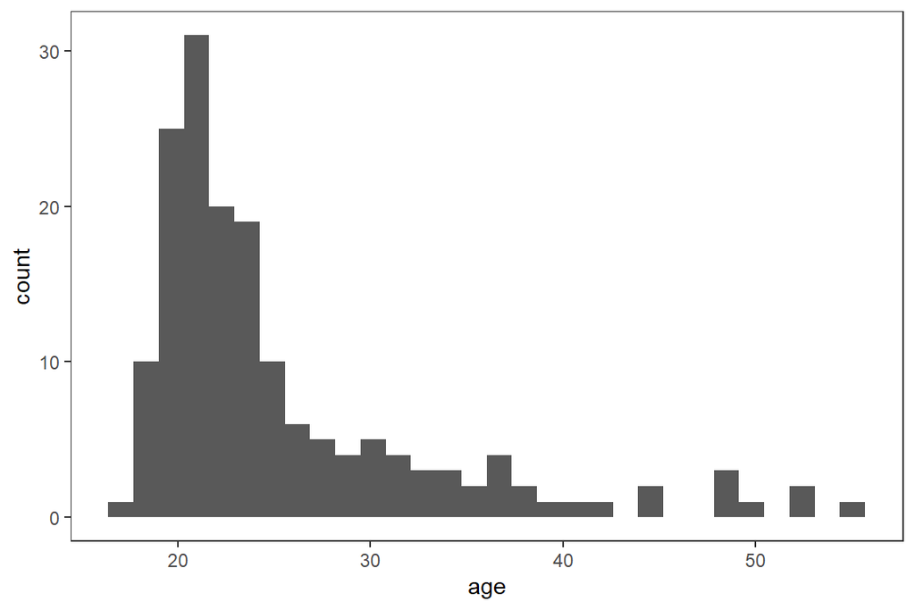

```r
# compute some random and very simple plots (not fancy plot adaptations made)
data %>% ggplot(aes(x = age)) +
  geom_histogram()
```

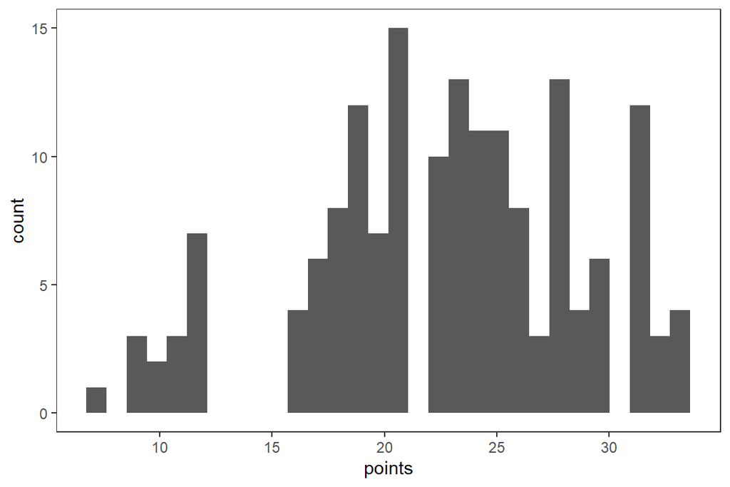

```r
data %>% ggplot(aes(x = points)) +
  geom_histogram()
```

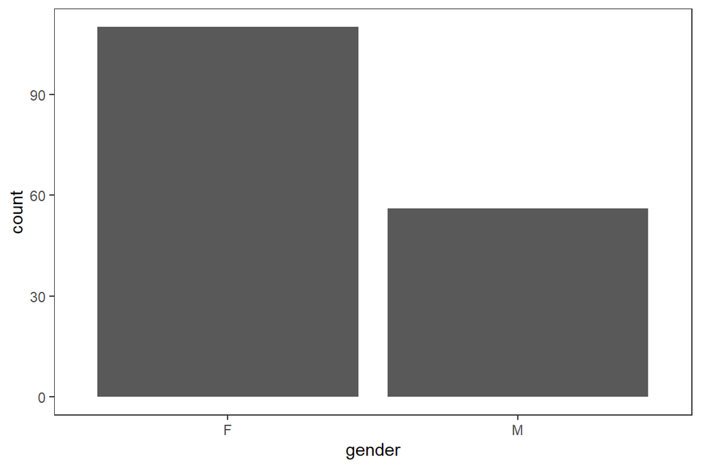

```r
data %>% ggplot(aes(x = gender)) +
  geom_bar()
```

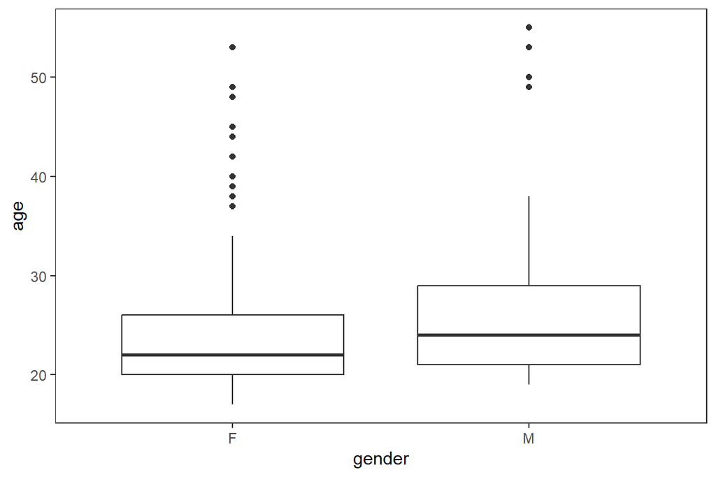

```r
data %>% ggplot(aes(y = age, x = gender)) +
  geom_boxplot()
```

```r
# provide summary for all variables
summary(data)
```

```
##  gender       age           attitude          deep            stra
##  F:110   Min.   :17.00   Min.   :1.400   Min.   :1.583   Min.   :1.250
##  M: 56   1st Qu.:21.00   1st Qu.:2.600   1st Qu.:3.333   1st Qu.:2.625
##          Median :22.00   Median :3.200   Median :3.667   Median :3.188
##          Mean   :25.51   Mean   :3.143   Mean   :3.680   Mean   :3.121
##          3rd Qu.:27.00   3rd Qu.:3.700   3rd Qu.:4.083   3rd Qu.:3.625
##          Max.   :55.00   Max.   :5.000   Max.   :4.917   Max.   :5.000
##       surf           points
##  Min.   :1.583   Min.   : 7.00
##  1st Qu.:2.417   1st Qu.:19.00
##  Median :2.833   Median :23.00
##  Mean   :2.787   Mean   :22.72
##  3rd Qu.:3.167   3rd Qu.:27.75
##  Max.   :4.333   Max.   :33.00
```

**fitting some simple linear regressions and interpret the results**

I chose the ‘age’ of participants, their general ‘attitude’ to statistics and the ‘deep’ learning approach as predictors/explanatory variables to the dependence variable ‘points’ only additivly due to lack of information about possible interactions.

```r
# remember available variables
names(data)
```

```
## [1] "gender"   "age"      "attitude" "deep"     "stra"     "surf"     "points"
```

```r
# build linear models in tidyverse syntax
m1 <- data %>%
  lm(formula = points ~ age + attitude + deep, data = .)

# print output of the fitted models
m1 %>% summary() # the only significant predictor is attitude
```

```
##
## Call:
## lm(formula = points ~ age + attitude + deep, data = .)
##
## Residuals:
##     Min      1Q  Median      3Q     Max
## -17.206  -3.430   0.204   3.979  10.950
##
## Coefficients:
##             Estimate Std. Error t value Pr(>|t|)
## (Intercept) 15.60773    3.38966   4.605 8.32e-06 ***
## age         -0.07716    0.05322  -1.450    0.149
## attitude     3.59413    0.56959   6.310 2.56e-09 ***
## deep        -0.60275    0.75031  -0.803    0.423
## ---
## Signif. codes:  0 '***' 0.001 '**' 0.01 '*' 0.05 '.' 0.1 ' ' 1
##
## Residual standard error: 5.307 on 162 degrees of freedom
## Multiple R-squared:  0.2043, Adjusted R-squared:  0.1896
## F-statistic: 13.87 on 3 and 162 DF,  p-value: 4.305e-08
```

```r
# fit new model without unsignificant predictors
m2 <- data %>%
  lm(formula = points ~ attitude, data = .)

# print summary statistics of the new fitted model
m2 %>% summary()
```

```
##
## Call:
## lm(formula = points ~ attitude, data = .)
##
## Residuals:
##      Min       1Q   Median       3Q      Max
## -16.9763  -3.2119   0.4339   4.1534  10.6645
##
## Coefficients:
##             Estimate Std. Error t value Pr(>|t|)
## (Intercept)  11.6372     1.8303   6.358 1.95e-09 ***
## attitude      3.5255     0.5674   6.214 4.12e-09 ***
## ---
## Signif. codes:  0 '***' 0.001 '**' 0.01 '*' 0.05 '.' 0.1 ' ' 1
##
## Residual standard error: 5.32 on 164 degrees of freedom
## Multiple R-squared:  0.1906, Adjusted R-squared:  0.1856
## F-statistic: 38.61 on 1 and 164 DF,  p-value: 4.119e-09
```

```r
# provide model comparison table for two fitted linear models
print(compareLM(m1, m2)) # m2 should be selected because of parsimony (lower AIC)
```

```
## $Models
##   Formula
## 1 "points ~ age + attitude + deep"
## 2 "points ~ attitude"
##
## $Fit.criteria
##   Rank Df.res  AIC AICc  BIC R.squared Adj.R.sq   p.value Shapiro.W Shapiro.p
## 1    4    162 1031 1032 1047    0.2043   0.1896 4.305e-08    0.9793  0.013670
## 2    2    164 1030 1030 1039    0.1906   0.1856 4.119e-09    0.9739  0.003195
```

Model 1 consists of the formula points ~ age + attitude + deep. The summary statistics provide model characteristics to interpret the fit and significance of single parameters. The intercept of the model function is 15.60773, so the intersection with the y-axis at x = 0 and it seems to be highly significant with three *** (p-value = 8.32e-06). In addition the attitude has a positive impact on the output variable (points) (provided by the slope): each unit ‘attitude’ seems to increase points per 3.5 units. Also this predictor is highly significant (p-value = 2.56e-09). The other predictors are not significant, so we cannot be sure that the effect of these predictors on the dependent variable is true (p-values of 0.149 for age and 0.423 for deep learning approach, respectively). All in all the model explaines 20.43 of the variability in the data - which means that there are 100-20.43 = 79.57 percent unexplained variability in the data (r-squared) and the adjusted r-squared (with penalty for every added parameter). There are 162 degrees of freedom.

After removing the statistically not significant predictors ‘age’ and ‘deep’ learning approach, the model 2 explained slightly less variability in the data. In addition, the adjusted r-squared had only a value of 0.1856.

By using the function compareLM() I computed a model comparison model, providing AIC, AICc, BIC for model comparison. NB: Don’t mix information theory approaches and p-value related model selection techniques. Even though, the more parsimonous model seems to be favoured by AIC and AICc.

The final model 2 has an intercept (y value at x = 0) of 11.6372 and a slope of 3.5255 for the predictor ‘attitude’. Both intercept and attitude parameters/estimates are significant, the computed standard errors are ~1.8 units and ~0.5 units, respectively. All in all, ‘attitude’ of the participants of this statistics course seems to have a positive impact on points in the exam (per unit in ‘attitude’ the mean number of points increases by ~3.5 units).

**Provide diagnostic plots of the fitted models**

To check linear model assumptions its common to provide some plots checking for any violations in the dataset.

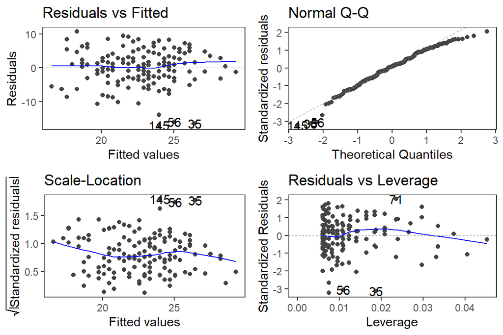

```r
# plot(m2) # its possible to simply plot the model with the baseR plot function
autoplot(m2) # do the same with the 'ggfortify' package
```

The diagnostic plots show 4 different relationships:

1. Residuals vs Fitted values
2. Normal QQ-plot
3. Standardized Residuals vs Fitted Values
4. Residuals vs Leverage

By them its possible to check for the four assumptions that have to be fullfilled by the dataset: a) Linear relationship between predictors and outcome; b) Independence of residuals; c) Normal distribution of residuals; d) Equal variance of residuals (Harrison and Pius, 2021).

1. The plot seems to indicate that there are some issues with independence of residuals: Somehow the residual distribution for higher fitted values seems to decrease. The assumption of constant variance is not justified. maybe this issue can be solved by transforming the data.
2. Plot to shows the theoretical quantiles against standardised residuals, by this we can check if the required normal distribution of the data is given. Also here are some issues with this: for low and high theoretical quantiles the distribution does not fit the assumption.
3. This plot is not needed here, its more an variation of plot 1)
4. This plots indicates, if single values have significant influence on the model fit. If all values are within the cooks distance everything is okay. Here I can’t observe any violations of these assumption.

**Plot relationship between ‘attitude’ and ‘points’**

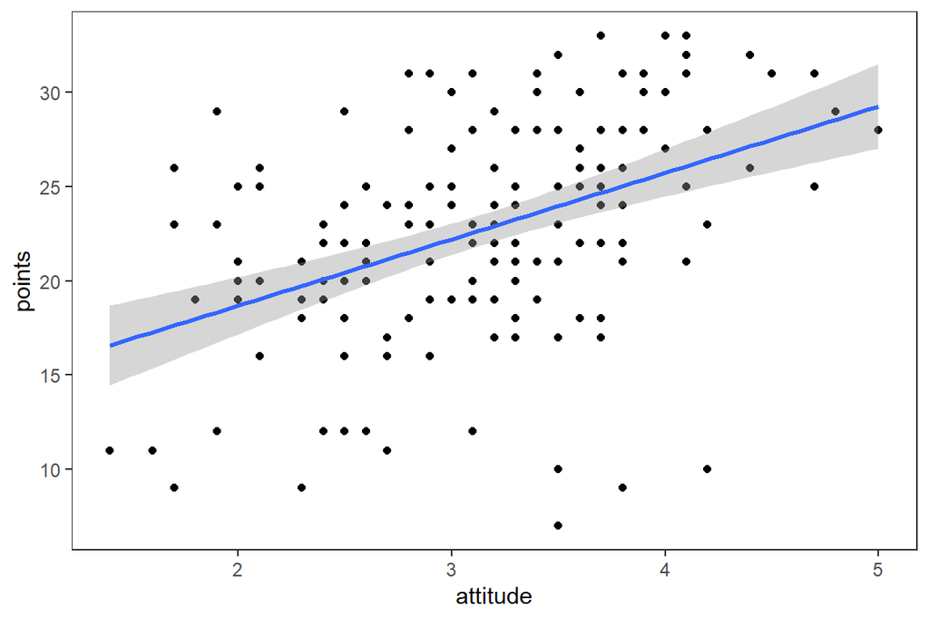

```r
data %>% ggplot(aes(x = attitude, y = points)) +
  geom_point() +
  geom_smooth(method = 'lm')
```

# Logistic regression

## This weeks self learning

This week I studied the recommended chapters from the ‘R for Health Data Science’ book. Afterwards, I worked on the given tasks and tried to describe everything properly in the Rmd file.

## Tasks in week 3

**Preparations and data description**

I loaded all necessary packages and save some functions in the global environment to avoid issues with identical named functions.

```r
library('tidyverse')
select <- dplyr::select
rename <- dplyr::rename
filter <- dplyr::filter
library('readr')
library('data.table')
library('rcompanion')
library(ggfortify)
theme_set(theme_test()) # set new 'default' theme for any ggplot
```

I load all necessary data for the analysis. The data has been prepared in the first tasks - this is not shown here but rather in the sript in my git repository. In addition, I use the prepared data set from the task to avoid getting troubles from any mistakes in the data preparation. Afterwards I explored the data to get an overview.

```r
# load data
data <- fread('https://raw.githubusercontent.com/KimmoVehkalahti/Helsinki-Open-Data-Science/master/datasets/alc.csv', sep = ',', header = T)

# data exploration
dim(data)
```

```
## [1] 370  35
```

```r
names(data)
```

```
##  [1] "school"     "sex"        "age"        "address"    "famsize"
##  [6] "Pstatus"    "Medu"       "Fedu"       "Mjob"       "Fjob"
## [11] "reason"     "guardian"   "traveltime" "studytime"  "schoolsup"
## [16] "famsup"     "activities" "nursery"    "higher"     "internet"
## [21] "romantic"   "famrel"     "freetime"   "goout"      "Dalc"
## [26] "Walc"       "health"     "failures"   "paid"       "absences"
## [31] "G1"         "G2"         "G3"         "alc_use"    "high_use"
```

```r
str(data)
```

```
## Classes 'data.table' and 'data.frame':   370 obs. of  35 variables:
##  $ school    : chr  "GP" "GP" "GP" "GP" ...
##  $ sex       : chr  "F" "F" "F" "F" ...
##  $ age       : int  18 17 15 15 16 16 16 17 15 15 ...
##  $ address   : chr  "U" "U" "U" "U" ...
##  $ famsize   : chr  "GT3" "GT3" "LE3" "GT3" ...
##  $ Pstatus   : chr  "A" "T" "T" "T" ...
##  $ Medu      : int  4 1 1 4 3 4 2 4 3 3 ...
##  $ Fedu      : int  4 1 1 2 3 3 2 4 2 4 ...
##  $ Mjob      : chr  "at_home" "at_home" "at_home" "health" ...
##  $ Fjob      : chr  "teacher" "other" "other" "services" ...
##  $ reason    : chr  "course" "course" "other" "home" ...
##  $ guardian  : chr  "mother" "father" "mother" "mother" ...
##  $ traveltime: int  2 1 1 1 1 1 1 2 1 1 ...
##  $ studytime : int  2 2 2 3 2 2 2 2 2 2 ...
```

[output cut: 22 more lines]

The given dataset belongs to a study that was made in Portuguese schools (secondary education). The data includes grades from period 1,2 (G1,G2) and the final grade (G3). Additionally, demographic information as well as information regarding the school and related features were gathered. Each primary table included data from different subjects: maths (mat) and portuguese language (por). NB: G3 is highly correlated with G1 and G2 due its calculation as final grade from both period 1 and period 2 grades. Its much harder to predict the final grade without information about grades from period 1 and period 2. To go more in detail, there are all in all 370 observations (students) with all in all 35 variables available in the given data-set. The names of the variables are visible in the output of names(data), from my point of view there is no need to further describe them except of the following:

- G1, G2 and G3: grades for certain subjects between 0 and 15, G3 is the final grade that is computed from G1 and G2
- age: students age in years
- absences: number of lessons not present in class

**Working hypothesis**

Although, the data description available online (link) seems to be more focused more on parameters leading to certain grades in maths and the portuguese language lectures we will investigate the influence between high and low alcohol consumption and some selected variables available in the dataset. I will work on the four variables selected from the dataset. Those are:

1. **age**: Maybe students with a higher age consume more (or the probability that they consume more is higher) alcohol because they had already more time to get used to alcohol consumption.
2. **absences**: I guess that higher absences could lead to higher alcohol consumption (or a higher probability to do so) due to a lot of freetime and maybe the underlaying problems that makes students missing classes.
3. **activities**: The presence of activities in freetime could lower alcohol consumption (pr a lower probability to consume alcohol).
4. **sex**: There are a lot of problematic stereotypes in this assumption but nevertheless, I guess for male students it is more likely to consume alcohol and to do so in higher amounts in comparison to female students.

**Explore chosen variables and their relationships to alcohol consumption**

I explored the chosen variables in the order they are shown above. After computing some simple plots and metrics I described the output. Afterwards, I go on to the next variable.

1. **age**

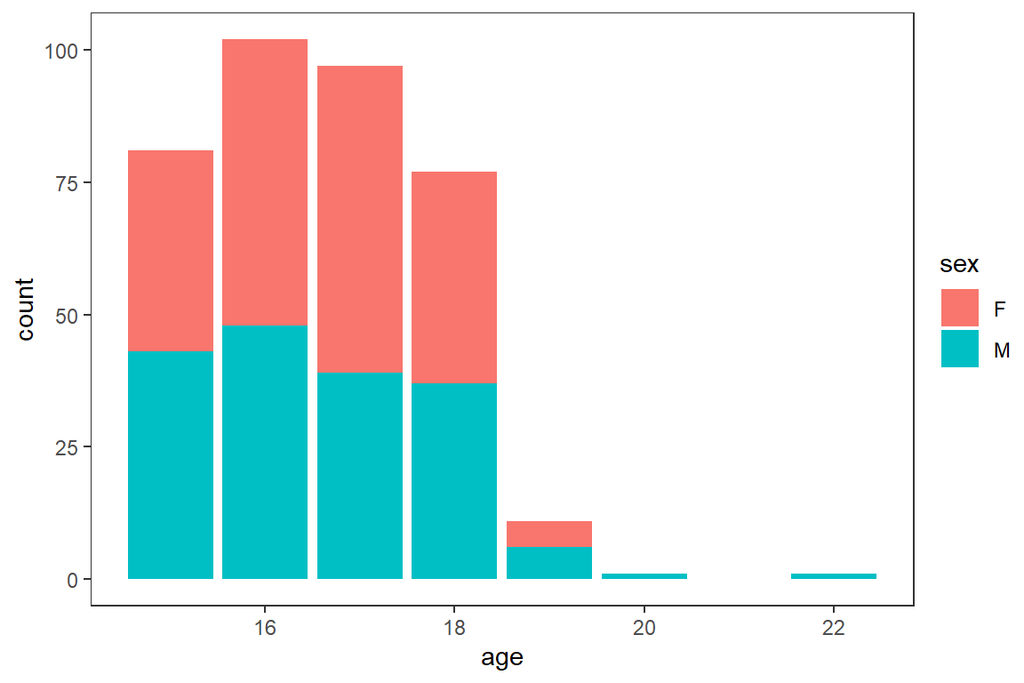

```r
data %>% ggplot(aes(x = age, fill = sex)) +
  geom_bar()
```

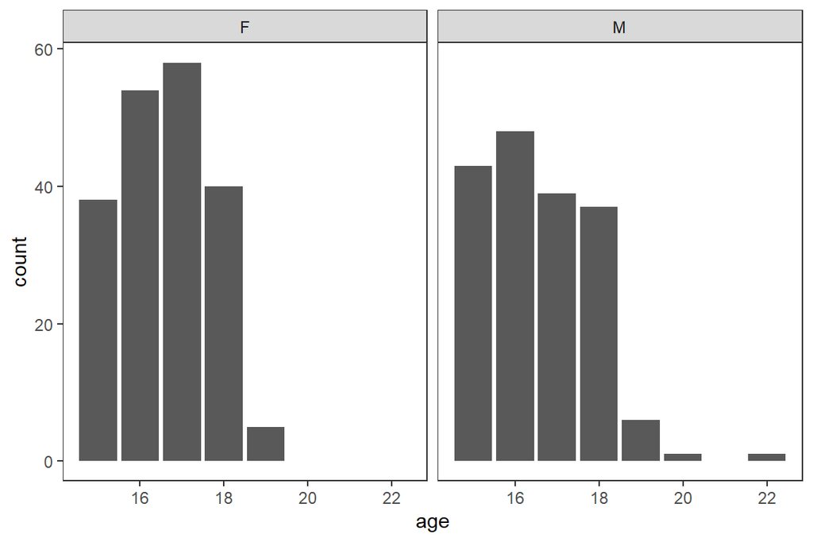

```r
data %>% ggplot(aes(x = age)) +
  geom_bar() +
  facet_wrap(~sex)
```

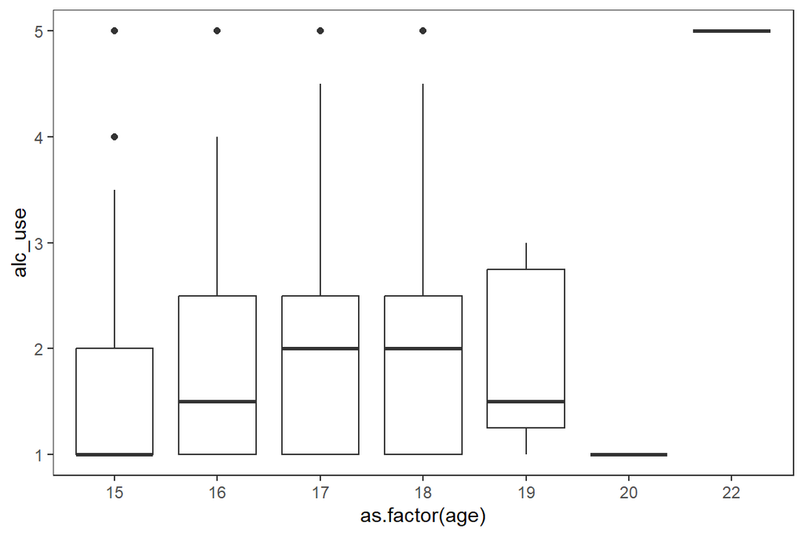

```r
data %>% ggplot(aes(x = as.factor(age), y = alc_use)) +
  geom_boxplot()
```

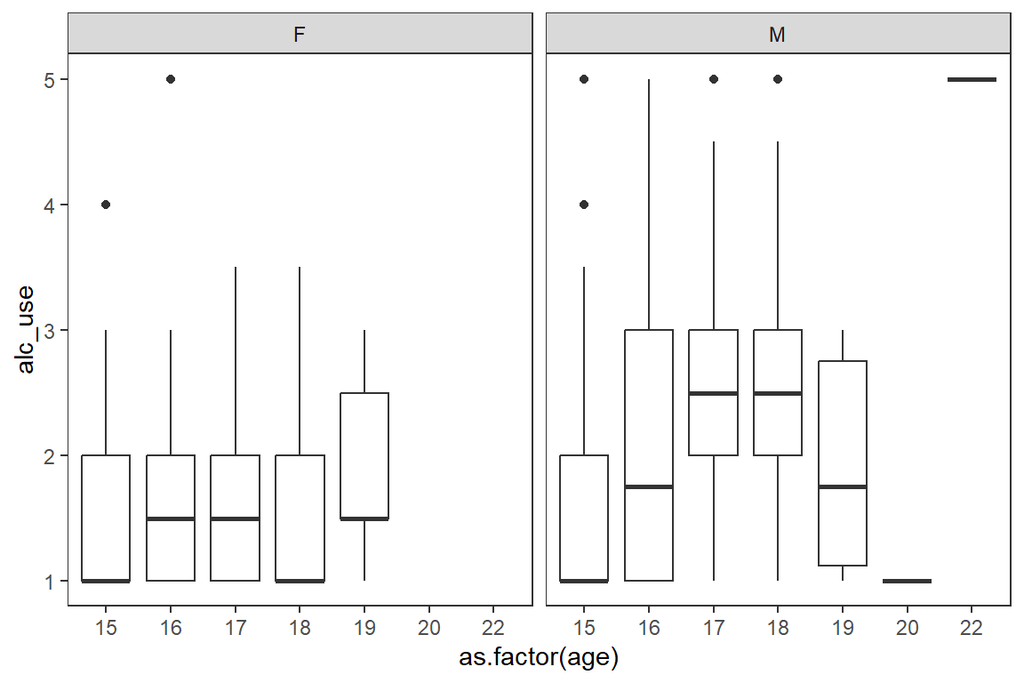

```r
data %>% ggplot(aes(x = as.factor(age), y = alc_use)) +
  geom_boxplot() +
  facet_wrap(~sex)
```

```r
mean(data$age)
```

```
## [1] 16.57568
```

The variable age has its mean at 16.58 years. Most students are between 15 and 19 years old, there are some students with the age of 19 and one of 20 and one of 22 years, respectively (both male). The age distribution does not differ significantly between male and female students. The relationship between age and alcohol consumption does not seem to be that straightforward like I thought. With the age of 17 or 18 the mean of alcohol consumption seems to have its peak which is caused mainly by the high alcohol consumption of males in this age class.

2. **absences**

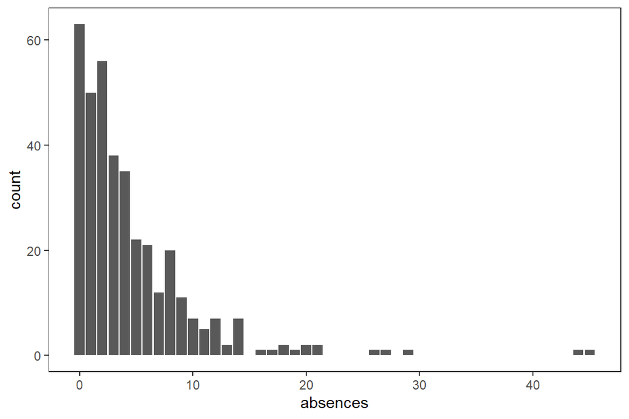

```r
data %>% ggplot(aes(x = absences)) +
  geom_bar()
```

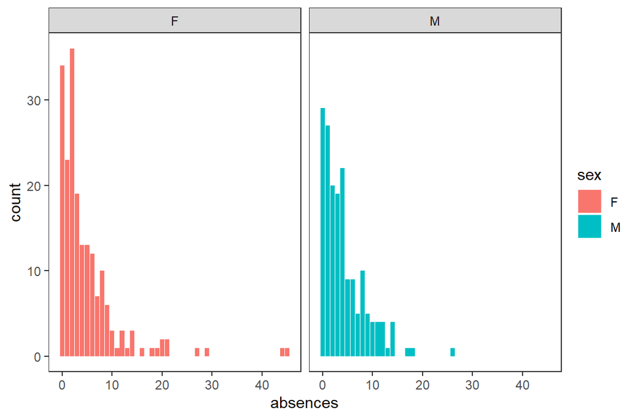

```r
data %>% ggplot(aes(x = absences, fill = sex)) +
  geom_bar() +
  facet_grid(~sex)
```

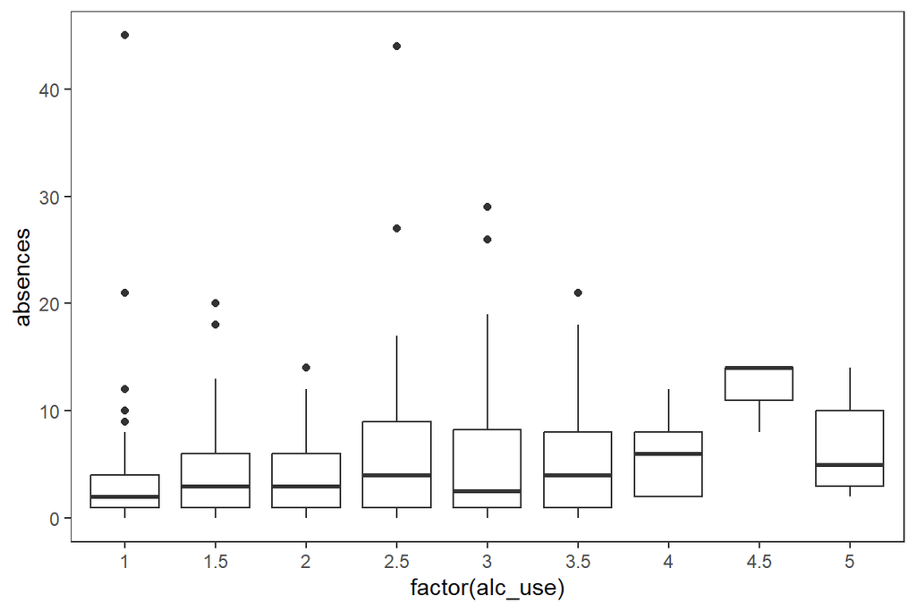

```r
data %>% ggplot(aes(y = absences, x = factor(alc_use))) +
  geom_boxplot()
```

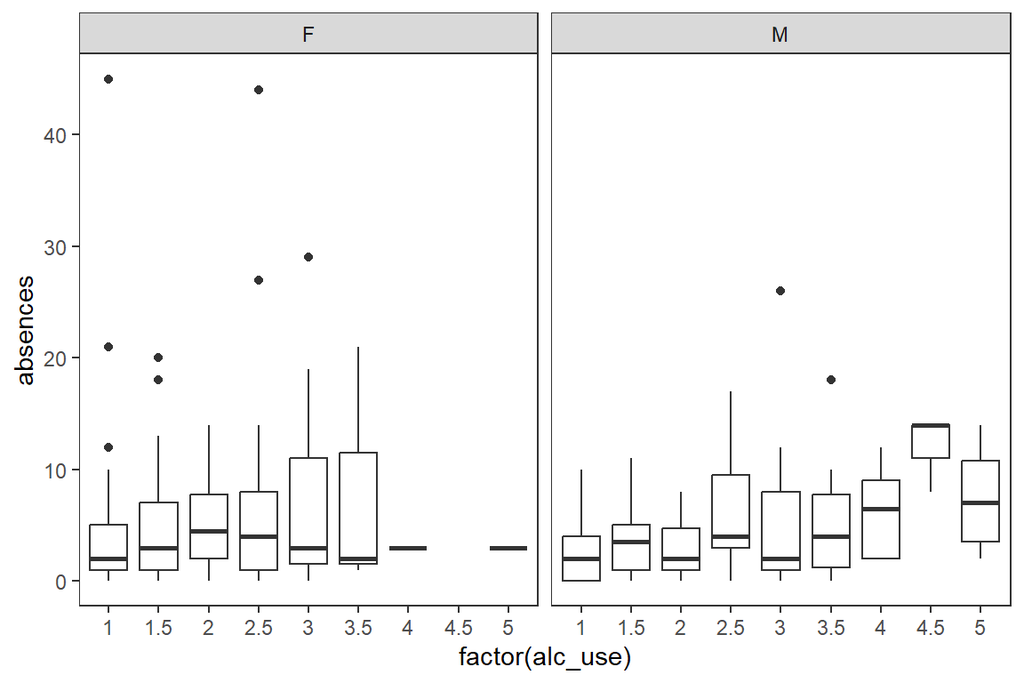

```r
data %>% ggplot(aes(y = absences, x = factor(alc_use))) +
  geom_boxplot() +
  facet_grid(~factor(sex))
```

The most abundant category of the variable absence is 0 which means that the student participated in every lecture of the class. The abundance of absences decreases the higher the values of absences get - for both male and female. The relationship between absence and alcohol consumption is not that clear but especially male students show a possible correlation between number of missed lectures and alcohol consumption. For female students this relationship is not that obvious and probably not existing.

3. **activities**

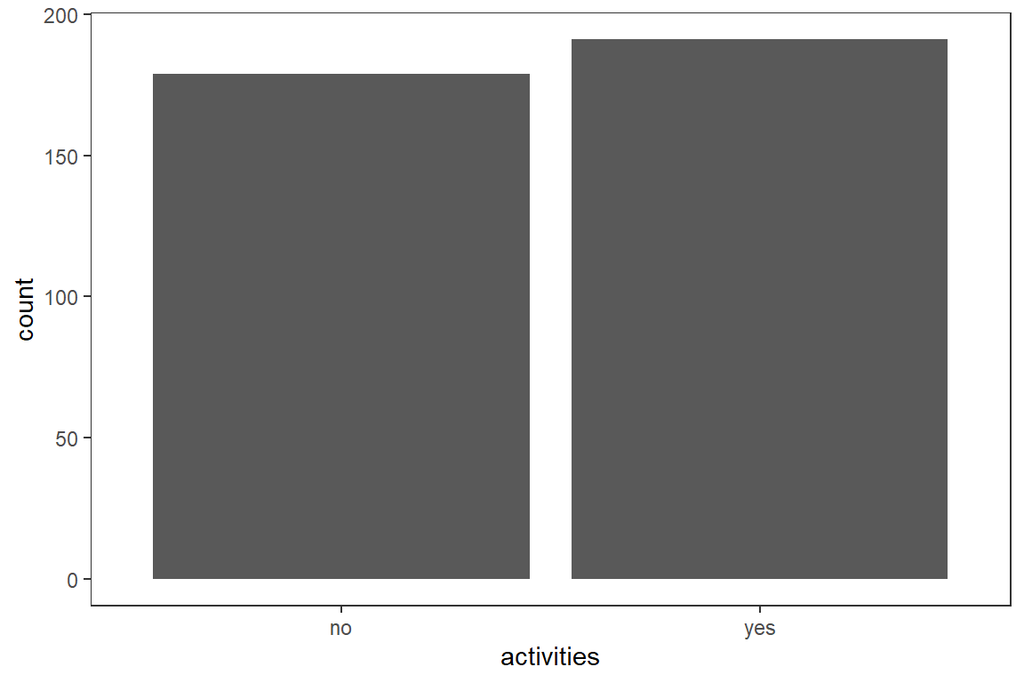

```r
data %>% ggplot(aes(x = activities)) +
  geom_bar()
```

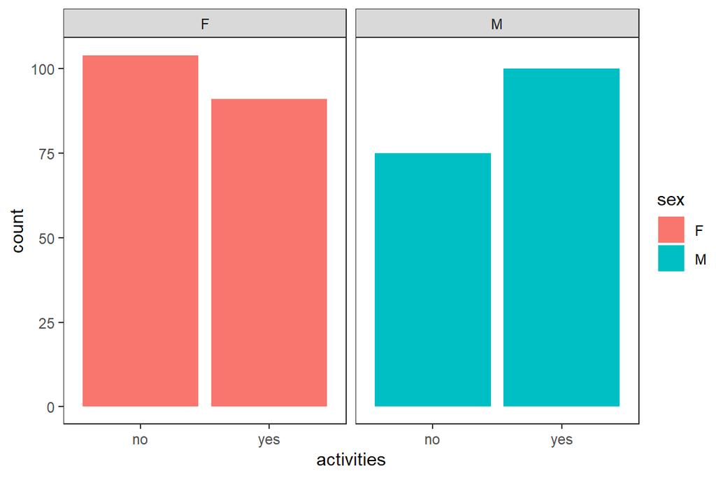

```r
data %>% ggplot(aes(x = activities, fill = sex)) +
  geom_bar() +
  facet_wrap(~sex)
```

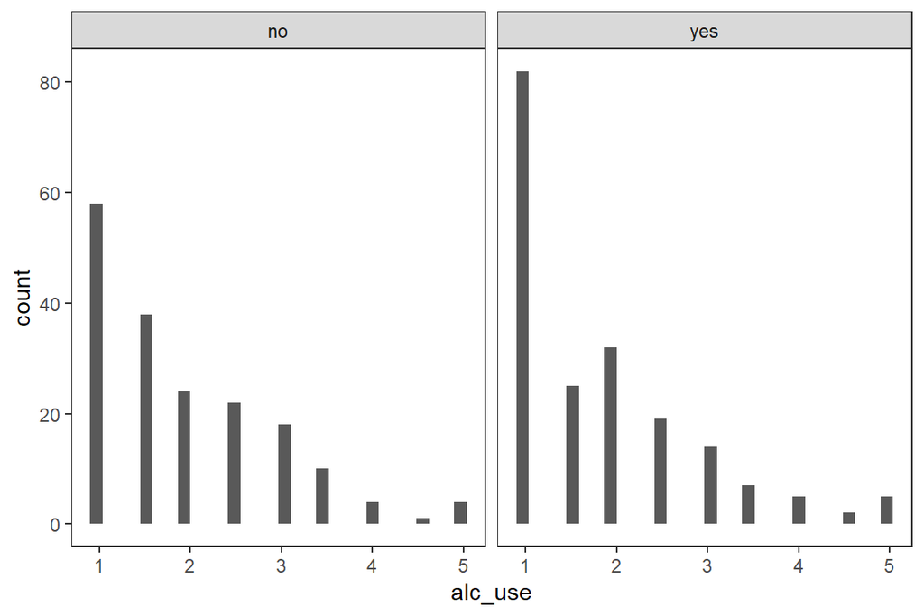

```r
data %>% ggplot(aes(x  = alc_use)) +
  geom_histogram() +
  facet_wrap(~activities)
```

Above all students the activity - variable seems to be even distributed. But splitting up by sex it shows a slightly different picture: male students more often (relative) have activities in their freetime. In contrast to this, female students show exactly the opposite pattern. Nevertheless, these differences seem to be very small and probably not significant. Interesting is the relationship between activites in freetime and alcohol consumption: The most abundant category of alcohol for students having activities in their freetime was 1. Even though this is also the case for people without activities in their freetime this pattern is much less pronounced there.

4. **sex**

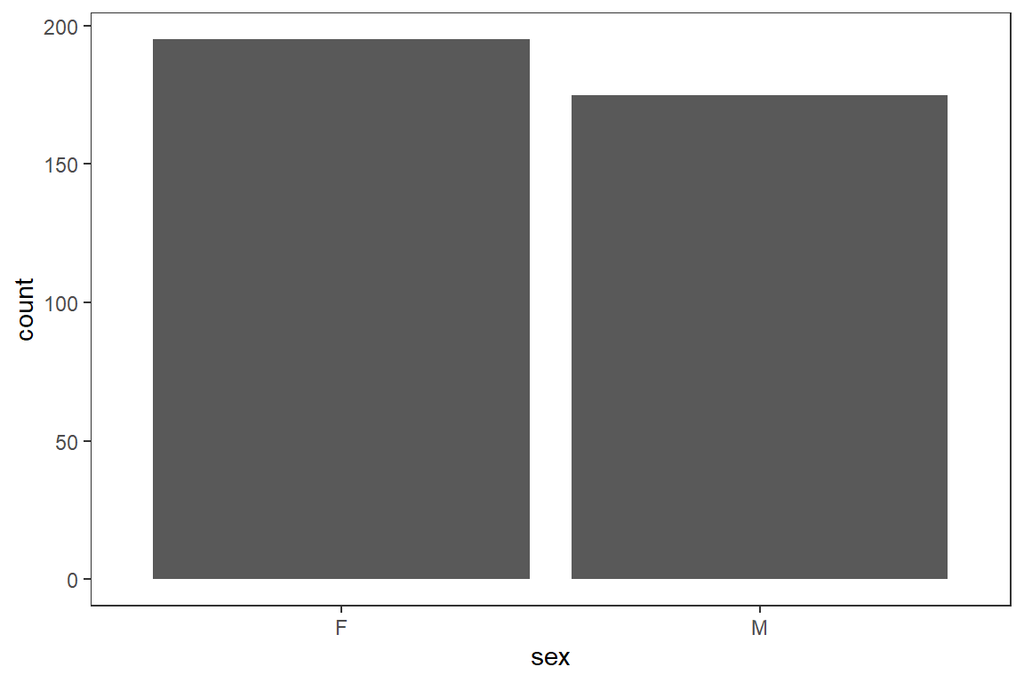

```r
data %>% ggplot(aes(x = sex)) +
  geom_bar()
```

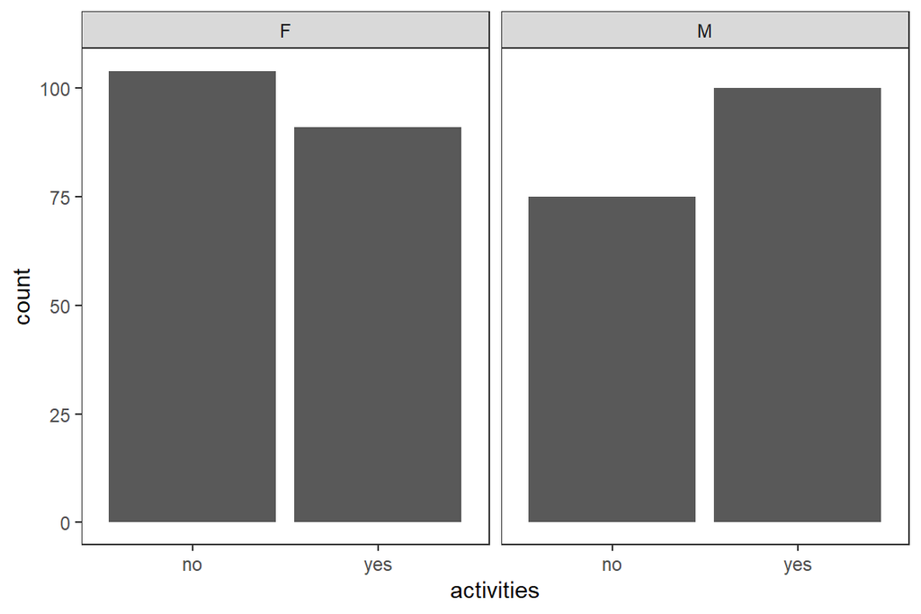

```r
data %>% ggplot(aes(x = activities)) + # I think is not new
  geom_bar() +
  facet_wrap(~sex)
```

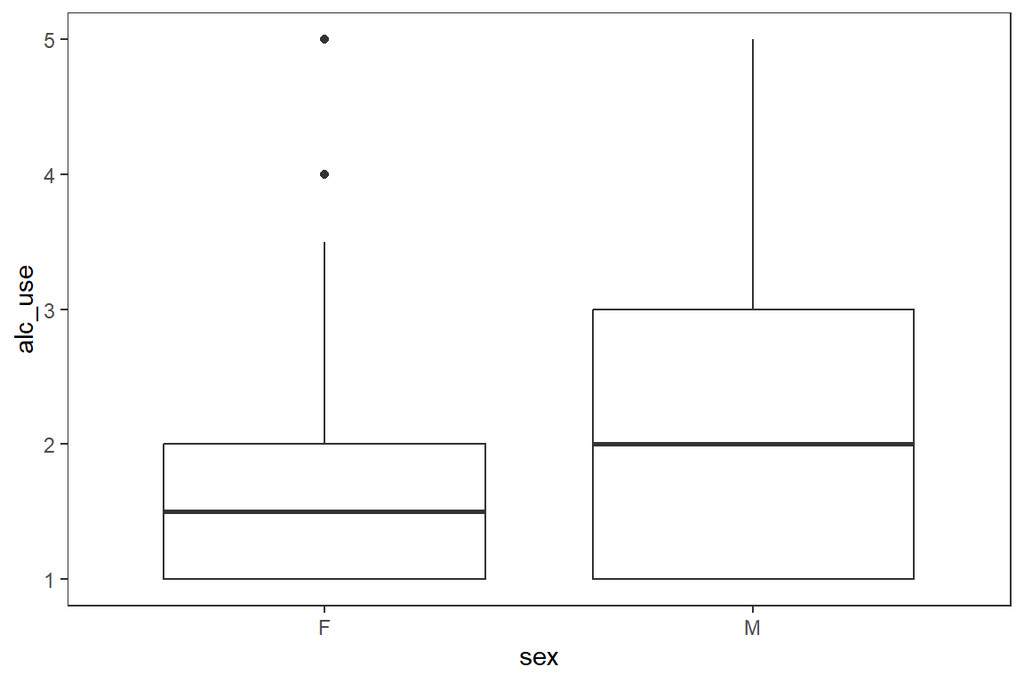

```r
data %>% ggplot(aes(x = sex, y = alc_use)) +
  geom_boxplot()
```

The dataset contains data from slightly less male than female students. In additon male students seem to have a slightly higher mean alcohol consumption than female students in general. Other plots regarding sex/gender of the students are shown above.

In addition, it is possible to compute some other tables providing an overview through the dataset.

**Fit logistic regression models**

This seems to be the main part of the task: explore the relationship between alcohol consumption and the chosen variables by fitting logistic regression models. First, I will fit the models (see below for exact fitting strategy) and compare them. Afterwards, I will extract interesting values and interpret the models as well as the values.

**Fitting strategy**

- parsimony
- account for variables that have been shown in previous studies to be related to target variable
- in health data science: always correct/include demographic parameters and background variables
- check individually for interactions and include them if needed
- final model selection by using AIC (AICc) and maximize c statistics

```r
# fitting model in baseR
# m1 <- glm(formula = alc_use ~ age, activities + sex + absences, data = data, family = binomial) # ah - I have to chose another alc_use variable, then probably my data exploration is not up to date, hope to have the time to able to update this

m1 <- glm(formula = high_use ~ age + activities + sex + absences, data = data, family = binomial) # with high_use as response variable
summary(m1)
```

```
##
## Call:
## glm(formula = high_use ~ age + activities + sex + absences, family = binomial,
##     data = data)
##
## Coefficients:
##               Estimate Std. Error z value Pr(>|z|)
## (Intercept)   -4.09219    1.72795  -2.368   0.0179 *
## age            0.14578    0.10277   1.419   0.1560
## activitiesyes -0.38837    0.24395  -1.592   0.1114
## sexM           1.08912    0.24841   4.384 1.16e-05 ***
## absences       0.09331    0.02338   3.991 6.57e-05 ***
## ---
## Signif. codes:  0 '***' 0.001 '**' 0.01 '*' 0.05 '.' 0.1 ' ' 1
##
## (Dispersion parameter for binomial family taken to be 1)
##
##     Null deviance: 452.04  on 369  degrees of freedom
## Residual deviance: 410.73  on 365  degrees of freedom
## AIC: 420.73
##
## Number of Fisher Scoring iterations: 4
```

```r
# fitting everything with finalfit package
library(finalfit)
dependent <- "high_use"
explanatory <- c("age", 'activities', 'sex', 'absences')
(m2 <- data %>%
  finalfit(dependent, explanatory, metrics = TRUE)) # metrics = T to see model metrics
```

```
## [[1]]
##  Dependent: high_use                FALSE       TRUE
##                  age Mean (SD) 16.5 (1.2) 16.8 (1.2)
##           activities        no 120 (67.0)  59 (33.0)
##                            yes 139 (72.8)  52 (27.2)
##                  sex         F 154 (79.0)  41 (21.0)
##                              M 105 (60.0)  70 (40.0)
##             absences Mean (SD)  3.7 (4.5)  6.4 (7.1)
##       Coefficient (univariable)    Coefficient (multivariable)
##    0.04 (0.00 to 0.08, p=0.042)  0.03 (-0.01 to 0.07, p=0.142)
##                               -                              -
##  -0.06 (-0.15 to 0.04, p=0.230) -0.07 (-0.16 to 0.02, p=0.111)
##                               -                              -
##    0.19 (0.10 to 0.28, p<0.001)   0.21 (0.12 to 0.30, p<0.001)
##    0.02 (0.01 to 0.03, p<0.001)   0.02 (0.01 to 0.03, p<0.001)
##
## [[2]]
##
##  Number in dataframe = 370, Number in model = 370, Missing = 0, Log-likelihood = -214.71, AIC = 441.4, R-squared = 0.11, Adjusted R-squared = 0.1
```

The task does not provide information if several different models should be fitted. Thus, I only fitted one global model with all selected variables I selected to explain high alcohol consumption. NB: Some of my variables seem to be seen as factors (sex with levels M and F; activities with levels yes and no). R deals with them by excluding one class and comparing the other class to this so called ‘base line class’. Normally, R orders the classes in an alphabetical order. To check how R actually treats it use options(“contrasts”). In this case of my fitted model R activities NO and sex female was used as reference class. Afterwards, a ‘test whether the pairwise difference between the coefficient of the reference class and the other class is different from zero or not’ is performed. The output from this test are the z and p-values in the model output. If only one category is significant this does not mean that the whole variable should be removed! The overall effect of the variable can be checked by an likelihood ratio test. All in all, the not removed levels in the model summary show the difference to the category that is not shown. The p- value behind indicates, if this difference is significant.

The model summary provides Estimates (but un-transformed to the natural scale, because of logit link), Standard deviation, z statistics and p-value. Additionally, the null and residual deviance with the degrees of freedom is shown. The AIC of the model is shown at the bottom of the output. The output of the model m1 shows significance for the intercept (p = 0.0179), and a significant (p = 1.16e-05) difference from sex m to base line category sex f. Furthermore, the variable absences seem to be significant too (p = 6.57e-05). All other variables are not significant.

For further interpretation especially of the OR I have to extract the estimates and transform them. This is done in the following r code chunk:

```r
# baseR approach
exp(coefficients(m1)) # exp() to back transform data from logit
```

```
##   (Intercept)           age activitiesyes          sexM      absences
##    0.01670258    1.15694394    0.67815848    2.97164574    1.09780607
```

```r
# approach from course book
coef(m1) %>% exp()
```

```
##   (Intercept)           age activitiesyes          sexM      absences
##    0.01670258    1.15694394    0.67815848    2.97164574    1.09780607
```

```r
confint(m1) %>% exp()
```

```
## Es wird auf das Profilieren gewartet ...
```

```
##                      2.5 %    97.5 %
## (Intercept)   0.0005374043 0.4774527
## age           0.9468150863 1.4178658
## activitiesyes 0.4188680255 1.0918685
## sexM          1.8388731060 4.8791285
## absences      1.0508116794 1.1518638
```

```r
# and further values and model characteristics
library(broom)
m1 %>% # simply an alternative from code above
  tidy(conf.int = TRUE, exp = TRUE)
```

```
## # A tibble: 5 × 7
##   term          estimate std.error statistic   p.value conf.low conf.high
##   <chr>            <dbl>     <dbl>     <dbl>     <dbl>    <dbl>     <dbl>
## 1 (Intercept)     0.0167    1.73       -2.37 0.0179    0.000537     0.477
## 2 age             1.16      0.103       1.42 0.156     0.947        1.42
## 3 activitiesyes   0.678     0.244      -1.59 0.111     0.419        1.09
## 4 sexM            2.97      0.248       4.38 0.0000116 1.84         4.88
## 5 absences        1.10      0.0234      3.99 0.0000657 1.05         1.15
```

```r
m1 %>% # extract model metrics
  glance()
```

```
## # A tibble: 1 × 8
##   null.deviance df.null logLik   AIC   BIC deviance df.residual  nobs
##           <dbl>   <int>  <dbl> <dbl> <dbl>    <dbl>       <int> <int>
## 1          452.     369  -205.  421.  440.     411.         365   370
```

**Explore predictive power of my model**

Task: explore predictive power of the model; 2X2 cross tabulation of predictors versus actual values, Compute the total proportion of inaccurately classified individuals (= the training error) and comment on all the results. Compare the performance of the model with performance achieved by some simple guessing strategy.

Unfortunately, I just saw that there is an extra Exercise provided - until now I studied everything by reading books (like the two provided books) and tried to do everything by myself and by reading some blocks. However, in this exercise this has not been possible anymore at the last task because I saw the exercise too late to work on it until the deadline. Nevertheless, I will study this later and will try to solve the task after submitting the assignment.

# 4: Clustering and classification

## This weeks self learning

This week I red the provided chapters 12, 17 and 18 from Vehkalahti, Kimmo & Everitt, Brian S. (2019). Additionally, I studied some of the topics from textbooks in my mother toung because sometimes I struggeled with understand all the new concepts immeadiately in english. I deepened the learning by doing the Exercise4.Rmd and now feel well prepared for doing the assignment 4.

## Tasks in week 4

### Preparations and data description**

I loaded all necessary packages and save some functions in the global environment to avoid issues with identical named functions.

```r
library('tidyverse')
select <- dplyr::select
rename <- dplyr::rename
filter <- dplyr::filter
library('MASS')
library('corrplot')
library('gridExtra')
library('factoextra')
library('cluster')
theme_set(theme_test()) # set new 'default' theme for any ggplot
```

I load all necessary data for the analysis. The data has been prepared in the first tasks - this is not shown here but rather in the sript in my git repository. In addition, I use the prepared data set from the task to avoid getting troubles from any mistakes in the data preparation. Afterwards I explored the data to get an overview.

```r
# load data
data("Boston")

# data exploration
dim(Boston)
```

```
## [1] 506  14
```

```r
names(Boston)
```

```
##  [1] "crim"    "zn"      "indus"   "chas"    "nox"     "rm"      "age"
##  [8] "dis"     "rad"     "tax"     "ptratio" "black"   "lstat"   "medv"
```

```r
str(Boston)
```

```
## 'data.frame':    506 obs. of  14 variables:
##  $ crim   : num  0.00632 0.02731 0.02729 0.03237 0.06905 ...
##  $ zn     : num  18 0 0 0 0 0 12.5 12.5 12.5 12.5 ...
##  $ indus  : num  2.31 7.07 7.07 2.18 2.18 2.18 7.87 7.87 7.87 7.87 ...
##  $ chas   : int  0 0 0 0 0 0 0 0 0 0 ...
##  $ nox    : num  0.538 0.469 0.469 0.458 0.458 0.458 0.524 0.524 0.524 0.524 ...
##  $ rm     : num  6.58 6.42 7.18 7 7.15 ...
##  $ age    : num  65.2 78.9 61.1 45.8 54.2 58.7 66.6 96.1 100 85.9 ...
##  $ dis    : num  4.09 4.97 4.97 6.06 6.06 ...
##  $ rad    : int  1 2 2 3 3 3 5 5 5 5 ...
##  $ tax    : num  296 242 242 222 222 222 311 311 311 311 ...
##  $ ptratio: num  15.3 17.8 17.8 18.7 18.7 18.7 15.2 15.2 15.2 15.2 ...
##  $ black  : num  397 397 393 395 397 ...
##  $ lstat  : num  4.98 9.14 4.03 2.94 5.33 ...
##  $ medv   : num  24 21.6 34.7 33.4 36.2 28.7 22.9 27.1 16.5 18.9 ...
```

The given data set called ‘Boston’ that is implemented in the R package ‘MASS’ provides information of 14 different variables on 506 Suburbs of Boston, Massachusetts. The data has been sampled long time ago - the first publication that is available on this data set has been published in 1978. In detail, the provided variables are: